# Quant: Final Exam

Samantha Page

12/4/2021

# Setup

## Load Libraries

```r
library(tidyverse)
library(interactions)
```

## Load Data

```r
data_main <- read_csv("exam_data_spage1.csv")
```

# Question 1

What is the average change in sales for Main Street businesses? Did sales increase or decrease, on average? How confident are you about that?

To solve, I will run a one-sample t-test.

```r
t.test(data_main$pct_sales_chng)
```

```
##
##  One Sample t-test
##
## data:  data_main$pct_sales_chng
## t = 22.949, df = 419, p-value < 2.2e-16
## alternative hypothesis: true mean is not equal to 0
## 95 percent confidence interval:
##  0.03570528 0.04239481
## sample estimates:
##  mean of x
## 0.03905004
```

On average, sales for Main Street businesses increased about 3.9% (the mean of x). The 95-percent confidence interval for the 3.9% increase is about 3.6 to 4.2 percent. Because the p-value for this estimate is less than 2.2 x 10^-16, close to 0, we can say with 99.9% confidence that the average change in sales increased.

# Question 2

Did the cost of parking change more for some types of businesses than for others? How confident are you about those differences?

To solve, I will run a bivariate regression.

First, I will find the most common store type.

```r
data_main %>%
  group_by(type) %>%
  summarise(number = n()) %>%
  mutate(percent =  round(100 *number / sum(number))) %>%
  arrange(desc(number))
```

```
## # A tibble: 7 x 3
##   type        number percent
##   <chr>        <int>   <dbl>
## 1 Clothing       120      29
## 2 Drugstore      112      27
## 3 Books           54      13
## 4 Restaurant      54      13
## 5 Grocery         40      10
## 6 Furniture       32       8
## 7 Gas station      8       2
```

Clothing stores are the most common types of stores, so I will compare all other stores back to that.

```r
data_main <- data_main %>%
  mutate(type = as.factor(type)) %>%
           mutate(type = relevel(type, "Clothing"))
```

Now I can run a bivariate regression to see what types of stores had changes in parking costs that differ from the changes for clothing stores.

```r
parking_cost_by_type <- lm(parking_cost_change ~ type, data = data_main)

summary(parking_cost_by_type)
```

```
##
## Call:
## lm(formula = parking_cost_change ~ type, data = data_main)
##
## Residuals:
##       Min        1Q    Median        3Q       Max
## -0.110133 -0.032907 -0.002133  0.029410  0.114867
##
## Coefficients:
##                  Estimate Std. Error t value Pr(>|t|)
## (Intercept)      0.092133   0.004247  21.693  < 2e-16 ***
## typeBooks        0.013737   0.007624   1.802 0.072300 .
## typeDrugstore    0.021170   0.006113   3.463 0.000589 ***
## typeFurniture   -0.078383   0.009257  -8.468 4.42e-16 ***
## typeGas station -0.079133   0.016989  -4.658 4.31e-06 ***
## typeGrocery     -0.057458   0.008494  -6.764 4.60e-11 ***
## typeRestaurant   0.062885   0.007624   8.248 2.17e-15 ***
## ---
## Signif. codes:  0 '***' 0.001 '**' 0.01 '*' 0.05 '.' 0.1 ' ' 1
##
## Residual standard error: 0.04653 on 413 degrees of freedom
## Multiple R-squared:  0.421,  Adjusted R-squared:  0.4126
## F-statistic: 50.05 on 6 and 413 DF,  p-value: < 2.2e-16
```

The average change in parking costs for clothing stores was an increase of about 9% (taken from the intercept of the regression). On average, bookstores had increases that were a little more than that, but because the p-value for bookstores is greater than 0.05 I am less than 95-percent confident that the difference is significant.

I am at least 95-percent confident that drugstores, furniture stores, gas stations, grocery stores, and restaurants had significantly different changes in parking costs compared to clothing stores:

- Parking costs at drugstores increased by about 2 percentage points more than at clothing stores.
- Parking costs at furniture stores increased, but by about 8 percentage points less than at clothing stores.
- Parking costs at gas stations also increased by about 8 percentage points less than at clothing stores.
- Parking costs at grocery stores increased, but by about 6 percentage points less than at clothing stores.
- Parking costs at restaurants increased by about 6 percentage points more than at clothing stores.

# Question 3

Not counting any kind of effect of the changes to parking and cycling have had, what kind of effect did it have on businesses if the closest transit stop got closer or further away?

To solve, I will run a multivariate regression model that will predict the effect of the change in distance to transit on the percent change in sales. We will hold constant changes in parking supply, changes in parking price, and changes in bike traffic.

```r
model1 <- lm(pct_sales_chng ~ transit_dist + lost_parking + parking_cost_change + bike_chng, data = data_main)

summary(model1)
```

```
##
## Call:
## lm(formula = pct_sales_chng ~ transit_dist + lost_parking + parking_cost_change +
##     bike_chng, data = data_main)
##
## Residuals:
##      Min       1Q   Median       3Q      Max
## -0.06712 -0.02077  0.00136  0.01943  0.07481
##
## Coefficients:
##                       Estimate Std. Error t value Pr(>|t|)
## (Intercept)          0.0348833  0.0039769   8.771  < 2e-16 ***
## transit_dist        -0.1984025  0.0247052  -8.031 1.01e-14 ***
## lost_parking        -0.0019003  0.0007259  -2.618  0.00917 **
## parking_cost_change  0.2127805  0.0247650   8.592  < 2e-16 ***
## bike_chng            0.1117582  0.0272498   4.101 4.95e-05 ***
## ---
## Signif. codes:  0 '***' 0.001 '**' 0.01 '*' 0.05 '.' 0.1 ' ' 1
##
## Residual standard error: 0.0284 on 415 degrees of freedom
## Multiple R-squared:  0.3429, Adjusted R-squared:  0.3366
## F-statistic: 54.15 on 4 and 415 DF,  p-value: < 2.2e-16
```

For every one-mile increase in the distance from a transit stop, sales decreased by about 20 percentage points, controlling for differences in the changes to parking supply, parking costs, and bike traffic.

# Question 4

Was the effect of transit on sales different for some types of businesses than for others? What was the difference, if any?

To solve this, I will estimate a regression model with an interaction between transit distance and business types. For consistency with the previous model, I will continue to control for changes to parking supply, parking costs, and cycling traffic.

```r
model2 <- lm(pct_sales_chng ~ type + transit_dist + lost_parking + parking_cost_change + bike_chng + type*transit_dist, data = data_main)

summary(model2)
```

```
##
## Call:
## lm(formula = pct_sales_chng ~ type + transit_dist + lost_parking +
##     parking_cost_change + bike_chng + type * transit_dist, data = data_main)
##
## Residuals:
##      Min       1Q   Median       3Q      Max
## -0.06627 -0.01128  0.00040  0.01160  0.05847
##
## Coefficients:
##                                Estimate Std. Error t value Pr(>|t|)
## (Intercept)                   0.0765109  0.0041650  18.370  < 2e-16 ***
## typeBooks                    -0.0009632  0.0060691  -0.159 0.873984
## typeDrugstore                 0.0082791  0.0050657   1.634 0.102967
## typeFurniture                -0.0862668  0.0065961 -13.078  < 2e-16 ***
## typeGas station              -0.0741477  0.0129927  -5.707 2.23e-08 ***
## typeGrocery                  -0.0840829  0.0071364 -11.782  < 2e-16 ***
## typeRestaurant               -0.0145700  0.0065309  -2.231 0.026236 *
## transit_dist                 -0.3042284  0.0307035  -9.909  < 2e-16 ***
## lost_parking                 -0.0016818  0.0004979  -3.378 0.000802 ***
## parking_cost_change          -0.0040758  0.0216772  -0.188 0.850954
## bike_chng                     0.0879314  0.0188169   4.673 4.05e-06 ***
## typeBooks:transit_dist        0.0029309  0.0574865   0.051 0.959363
## typeDrugstore:transit_dist   -0.0404619  0.0452357  -0.894 0.371606
## typeFurniture:transit_dist    0.3073764  0.0642802   4.782 2.44e-06 ***
## typeGas station:transit_dist  0.2951638  0.1278076   2.309 0.021424 *
## typeGrocery:transit_dist      0.2654912  0.0668356   3.972 8.43e-05 ***
## typeRestaurant:transit_dist   0.1609856  0.0588093   2.737 0.006467 **
## ---
## Signif. codes:  0 '***' 0.001 '**' 0.01 '*' 0.05 '.' 0.1 ' ' 1
##
## Residual standard error: 0.01939 on 403 degrees of freedom
## Multiple R-squared:  0.7026, Adjusted R-squared:  0.6908
## F-statistic:  59.5 on 16 and 403 DF,  p-value: < 2.2e-16
```

Yes, the effect of distance to transit on sales was different for some types of businesses than others.

For furniture stores, gas stations, and grocery stores, the distance to transit did not have a substantial effect on the change in sales. I found this result by adding the coefficient of the transit distance (-30 percentage points) with the coefficients of furniture:transit_dist (about 31 percentage points), gas station:transit_dist (about 30 percentage points), and grocery:transit_dist (about 27 percentage points), which makes the effect for these types of stores close to 0.

For clothing stores, bookstores, and drugstores, each additional one-mile increase in the distance from a transit stop was associated with an additional 30 percentage point decrease in sales.

For restaurants, each additional one-mile increase in the distance from a transit stop was associated with an additional 14 percentage point decrease in sales. This result was found by adding the -30 percentage points from the transit distance coefficient to the 16 percentage points of the restaurant:transit_dist coefficient.

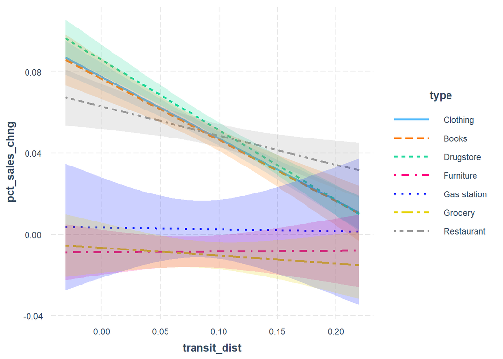

```r
interact_plot(model2, pred = transit_dist, interval = TRUE, modx = type)
```